# **What Makes a Football Player Valuable?**

### CMSC 320 | Spring 2026 Final Project Tutorial Transfer Market Trajectories

## Contributions

| Member | Sections | Summary |
| --- | --- | --- |
| Ethan Ta | B, C, D, E, F | Handled data preprocessing and EDA. Implemented Random Forest and did result analysis for both ML models. |
| Nikolos Migineishvili | B, C, E, F, G | Handled data preprocessing and EDA. Wrote analysis for both models and insights/conclusions section. Did final tutorial report creation. |
| Nathaniel Rubin | A, B, C, D, E | Proposed project idea and found dataset. Handled data preprocessing and EDA. Implemented four regression models. |
| Daryoush Nawabi | B, C, E, F | Handled data preprocessing and EDA. Did analysis and visualizations for both ML models. |

1. Introduction
2. Data Preprocessing
   - Imports
   - Loading Data
   - Parsing + Organizing
   - Data Quality Check
3. Exploratory Data Analysis
   - Distribution Analysis
   - Correlation Testing
   - Hypothesis Test 1: Pearson Correlation
   - Hypothesis Test 2: One-Way ANOVA
4. Primary Analysis: Machine Learning
   - Part 1: Classification (Random Forest)
   - Part 2: Regression (Peak Value Prediction)
5. Insights and Conclusions

## Introduction

The global football transfer market moves billions of euros every summer window. When clubs pay millions of euros for a player, what exactly are they paying for? Is it talent, age, career momentum, or something harder to quantify, like the trajectory of where a player seems to be heading?

We focus on two core questions:

1. **Can we predict a player's career trajectory class** (`rising_star`, `growing`, `stable`, `declining`, `falling_sharply`) from observable career statistics without using the trajectory label itself?
2. **How well can we predict a player's all-time peak market value** from early career features?

Answering these questions has practical stakes like transfer decisions, contracts, scouting analysts, etc.

## Data Preprocessing

See the **Loading Data**, **Parsing + Organizing**, and **Print Data** sections below. The dataset is the [Football Transfer Value Intelligence 2024](https://www.kaggle.com/datasets/kanchana1990/football-transfer-value-intelligence-2024) dataset from Kaggle. It contains two files:

- `transfermarkt_player_values.csv`: one row per player with aggregated career statistics
- `transfermarkt_value_history.csv`: time-series valuation snapshots

Dates were parsed to `datetime`, the history dataset's day-first format was handled with `format="%d/%m/%Y"`, missing age values were imputed from the history table, and the seven players with unresolvable missing values were handled via median/placeholder fill.

**Imports**

```python
import pandas as pd
```

**Loading Data**

```python
players = pd.read_csv(
    "datasets/kanchana1990/football-transfer-value-intelligence-2024/versions/1/Football_Player_Market_Value_Trajectories/transfermarkt_player_values.csv"
)

history = pd.read_csv(
    "datasets/kanchana1990/football-transfer-value-intelligence-2024/versions/1/Football_Player_Market_Value_Trajectories/transfermarkt_value_history.csv"
)
```

**Parsing + Organizing**

```python
# Convert date columns in players dataset to datetime
players["peak_date"] = pd.to_datetime(players["peak_date"], errors="coerce")
players["first_date"] = pd.to_datetime(players["first_date"], errors="coerce")
players["last_date"] = pd.to_datetime(players["last_date"], errors="coerce")
players["dataset_built_at"] = pd.to_datetime(players["dataset_built_at"], errors="coerce")

# Convert valuation_date in history dataset to datetime
history["valuation_date"] = pd.to_datetime(
    history["valuation_date"], format="%d/%m/%Y", errors="coerce"
)

# Sort players alphabetically by name
players = players.sort_values(by="name").reset_index(drop=True)

# Add player names to history dataset using player_id
history["name"] = history["player_id"].map(players.set_index("player_id")["name"])

# Reorder columns so name is next to player_id
cols = history.columns.tolist()
cols.remove("name")
cols.insert(1, "name")
history = history[cols]

# Sort history by name (A-Z) and valuation_date (most recent first)
history = history.sort_values(
    by=["name", "valuation_date"],
    ascending=[True, False]
).reset_index(drop=True)
```

**Print Data + Check for any missing/duplicates**

```python
print("\nPlayers First 5 rows:")
print(players.head())

print("\nPlayers Info:")
print(players.info())

print("\nHistory First 5 rows:")
print(history.head())

print("\nHistory Info:")
print(history.info())

print("\nMissing values per column:")
print(players.isnull().sum())

# Show rows where age OR nationality is missing
missing_rows = players[players[["age", "nationality"]].isnull().any(axis=1)]

print("\nRows with missing age or nationality:")
print(missing_rows[["player_id", "name", "age", "nationality"]])

# Fill missing age using the closest valuation date in history
best_age = (
  players.loc[players["age"].isna(), ["player_id", "last_date"]]
  .merge(
      history[["player_id", "valuation_date", "age_at_date"]],
      on="player_id",
      how="left"
  )
  .assign(date_diff=lambda df: (df["valuation_date"] - df["last_date"]).abs())
  .sort_values(["player_id", "date_diff", "valuation_date"])
  .drop_duplicates("player_id")
  .set_index("player_id")["age_at_date"]
)

players["age"] = players["age"].fillna(players["player_id"].map(best_age))

# Optional fallback in case any age is still missing
players["age"] = players["age"].fillna(players["age"].median())

# Fill nationality with placeholder
players["nationality"] = players["nationality"].fillna("Unknown")

bad_cols = ["position", "position_group", "current_club"]

players = players.drop(columns=[c for c in bad_cols if c in players.columns])

print("\nMissing values after cleaning:")
print(players[["age", "nationality"]].isnull().sum())

print("\nCheck if any duplicates exist")
print(players.duplicated().any())
```

```
Players First 5 rows:
   player_id                name   age nationality position position_group  \
0    1145504     Aarón Anselmino  20.0   Argentina  €12.00m          Other
1     724520     Abde Ezzalzouli  24.0     Morocco  €20.00m          Other
2     763079  Abdukodir Khusanov  21.0  Uzbekistan  €35.00m          Other
3     398073       Achraf Hakimi  27.0     Morocco  €80.00m          Other
4     744149        Adam Wharton  39.0     England  €60.00m          Other

  current_club     league_name  current_value_eur current_value_tier  ...  \
0    Argentina         Ligue 1         12000000.0    Regular (5-20M)  ...
1      Morocco         La Liga         20000000.0       Top (20-50M)  ...
2   Uzbekistan  Premier League         35000000.0       Top (20-50M)  ...
3      Morocco         Ligue 1         80000000.0    Elite (50-100M)  ...
4      England  Premier League         60000000.0    Elite (50-100M)  ...

   mean_yoy_growth_rate num_valuation_points num_clubs_career   trajectory  \
0                4.9277                    7                4  rising_star
1                4.0163                   18                4  rising_star
2                2.9443                   12                3      growing
3                1.7988                   29                5      growing
4                1.5195                   10                2      growing

   is_at_peak  ever_100m ever_50m  ever_10m        data_source  \
0           1          0        0         1  Transfermarkt.com
1           1          0        0         1  Transfermarkt.com
2           0          0        0         1  Transfermarkt.com
3           0          0        1         1  Transfermarkt.com
4           0          0        1         1  Transfermarkt.com

   dataset_built_at
0        2026-02-21
1        2026-02-21
2        2026-02-21
3        2026-02-21
4        2026-02-21

[5 rows x 36 columns]

Players Info:
<class 'pandas.core.frame.DataFrame'>
```

[output cut: 119 more lines]

```
148     533354    Facundo Garcés  NaN         NaN
211    1063574         Jan Salas  NaN         NaN
276     387626       Leon Bailey  NaN         NaN
285     572265     Lorenzo Lucca  NaN         NaN
393    1232057       Paco Cortés  NaN         NaN
459     522784  Taty Castellanos  NaN         NaN
504    1124136       Ángel Pérez  NaN         NaN

Missing values after cleaning:
age            0
nationality    0
dtype: int64

Check if any duplicates exist
False
```

## Exploratory Data Analysis

These findings guide our ML feature selection below.

**Distribution (Descriptive stats + visualization)**

```
Summary Statistics for Player Market Value:
count    5.080000e+02
mean     3.686693e+07
std      2.770602e+07
min      3.000000e+05
25%      2.000000e+07
50%      2.800000e+07
75%      4.500000e+07
max      2.000000e+08
Name: current_value_eur, dtype: float64
```

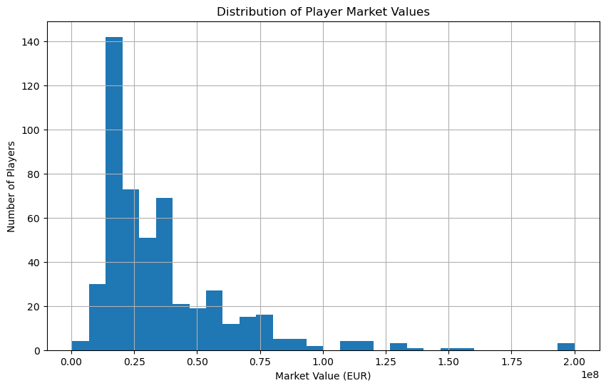

```python
import matplotlib.pyplot as plt

print("Summary Statistics for Player Market Value:")
print(players["current_value_eur"].describe())

# --- Histogram (Distribution Visualization) ---
plt.figure(figsize=(10,6))

players["current_value_eur"].hist(bins=30)

plt.title("Distribution of Player Market Values")
plt.xlabel("Market Value (EUR)")
plt.ylabel("Number of Players")

plt.show()
```

**Descriptive Statistics and Distribution Analysis**

The dataset contains 508 players with market values measured in euros. The mean market value is approximately 36.9 million euros, while the median is 28 million euros. The mean being larger than the median indicates a right-skewed distribution, where a small number of players have extremely high values that pull the average upward, as shown in graph. The standard deviation (~27.7 million euros) is relatively large, showing that player values vary significantly across the dataset. The minimum is 300,000 euros, while the maximum is 200 million euros.

The histogram visualization further supports these facts. Most players are concentrated in the lower to mid ranges, while only a few players fall into the highest ranges. This illustrates that high-value players act as outliers and contribute to the skewness of the distribution.

**Correlation Testing**

```
Correlation Matrix:
                       current_value_eur       age  peak_value_eur  \
current_value_eur               1.000000 -0.095507        0.899292
age                            -0.095507  1.000000       -0.025733
peak_value_eur                  0.899292 -0.025733        1.000000
age_at_peak                    -0.005261  0.317910        0.059749
career_span_years               0.035129  0.308047        0.251865
years_to_peak                   0.085963  0.264302        0.155483
value_cagr                     -0.024022 -0.075885       -0.035926
value_to_peak_cagr             -0.024429 -0.074753       -0.036428
value_multiplier_x              0.243084  0.126384        0.259119
post_peak_decline_pct          -0.201017  0.181365        0.196785
value_volatility               -0.154668 -0.043632       -0.262018
mean_yoy_growth_rate           -0.057069 -0.164723       -0.128703
num_valuation_points            0.106924  0.303364        0.320735
num_clubs_career               -0.069203  0.205870       -0.046257

                       age_at_peak  career_span_years  years_to_peak  \
current_value_eur        -0.005261           0.035129       0.085963
age                       0.317910           0.308047       0.264302
peak_value_eur            0.059749           0.251865       0.155483
age_at_peak               1.000000           0.718896       0.891069
career_span_years         0.718896           1.000000       0.815333
years_to_peak             0.891069           0.815333       1.000000
value_cagr               -0.109693          -0.117278      -0.112856
value_to_peak_cagr       -0.113459          -0.120003      -0.116852
value_multiplier_x        0.231362           0.285660       0.262667
post_peak_decline_pct     0.184984           0.559319       0.199012
value_volatility          0.051328          -0.188412       0.044308
mean_yoy_growth_rate     -0.337751          -0.428235      -0.379274
num_valuation_points      0.689906           0.967597       0.777181
num_clubs_career          0.452873           0.470130       0.509965

                       value_cagr  value_to_peak_cagr  value_multiplier_x  \
current_value_eur       -0.024022           -0.024429            0.243084
age                     -0.075885           -0.074753            0.126384
peak_value_eur          -0.035926           -0.036428            0.259119
age_at_peak             -0.109693           -0.113459            0.231362
career_span_years       -0.117278           -0.120003            0.285660
years_to_peak           -0.112856           -0.116852            0.262667
```

[output cut: 41 more lines]

```
                       num_clubs_career
current_value_eur             -0.069203
age                            0.205870
peak_value_eur                -0.046257
age_at_peak                    0.452873
career_span_years              0.470130
years_to_peak                  0.509965
value_cagr                    -0.098885
value_to_peak_cagr            -0.100208
value_multiplier_x             0.165722
post_peak_decline_pct          0.143240
value_volatility               0.106993
mean_yoy_growth_rate          -0.258986
num_valuation_points           0.433522
num_clubs_career               1.000000
```

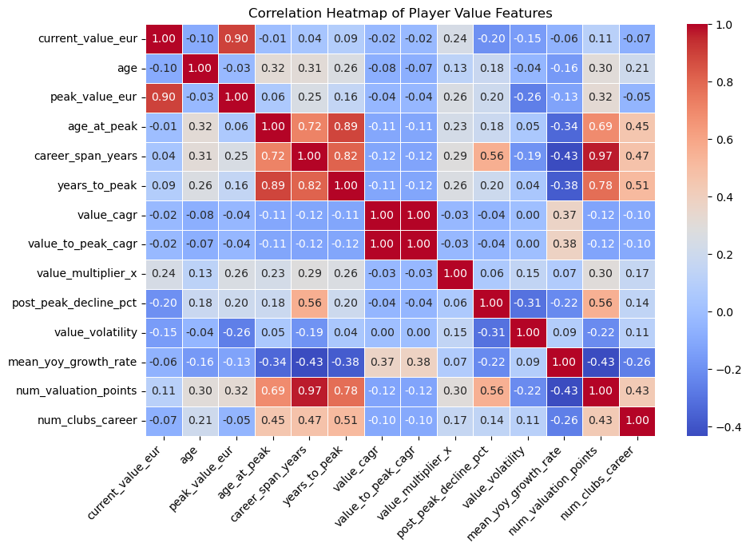

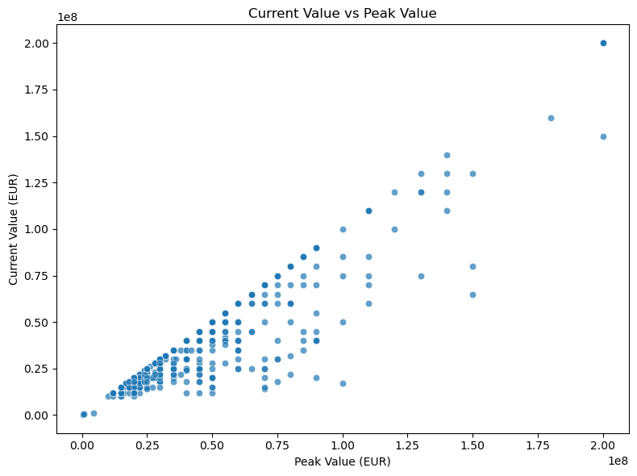

```python
import seaborn as sns

corr_cols = [
    "current_value_eur",
    "age",
    "peak_value_eur",
    "age_at_peak",
    "career_span_years",
    "years_to_peak",
    "value_cagr",
    "value_to_peak_cagr",
    "value_multiplier_x",
    "post_peak_decline_pct",
    "value_volatility",
    "mean_yoy_growth_rate",
    "num_valuation_points",
    "num_clubs_career"
]

corr_df = players[corr_cols].corr()

print("Correlation Matrix:")
print(corr_df)

plt.figure(figsize=(10, 7))
sns.heatmap(corr_df, annot=True, cmap="coolwarm", fmt=".2f", linewidths=0.5)
plt.title("Correlation Heatmap of Player Value Features")
plt.xticks(rotation=45, ha="right")
plt.yticks(rotation=0)
plt.tight_layout()
plt.show()

plt.figure(figsize=(8, 6))
sns.scatterplot(data=players, x="peak_value_eur", y="current_value_eur", alpha=0.7)
plt.title("Current Value vs Peak Value")
plt.xlabel("Peak Value (EUR)")
plt.ylabel("Current Value (EUR)")
plt.tight_layout()
plt.show()
```

**Correlation Testing**

The correlation heatmap shows that the strongest relationship involving a player’s current market value is with peak_value_eur (r = 0.90), indicating that players who reached higher historical peak values generally still maintain higher current values. In contrast, age has only a weak negative correlation with current_value_eur (r = -0.10), which suggests that market value is not determined simply by whether a player is younger or older.

Several of the other strong correlations also make intuitive sense because the variables measure closely related parts of a player’s career. For example, career_span_years and num_valuation_points are almost identical (r = 0.97) because players who have been tracked for more years naturally tend to accumulate more valuation records. Similarly, age_at_peak and years_to_peak are strongly correlated (r = 0.89) because players who take more years to reach their peak are usually older when that peak occurs. The perfect correlation between value_cagr and value_to_peak_cagr (r = 1.00) suggests these two growth measures behave nearly the same in this dataset.

In addition, mean_yoy_growth_rate has a moderate negative correlation with career_span_years (r = -0.43), which may mean that very large year-over-year growth is more common in shorter or earlier career periods. Finally, num_clubs_career is moderately related to years_to_peak (r = 0.51) and career_span_years (r = 0.47), which also makes sense because players with longer careers have had more time to move between clubs, even though this has almost no relationship with current_value_eur (r = -0.07).

**Hypothesis Testing (Pearson Correlation)**

We will conduct a hypothesis test, testing whether or not the number of clubs in the player's career has an effect on their market value. The hypotheses are as follows:

$H_0$: There is no relationship between the number of clubs a player has played for and their current market value.

$H_a$: There is a relationship between the number of clubs in a player’s career and their current market value.

We will use the Pearson Correlation test to conduct this hypothesis test.

The independent variable will be $num\_clubs\_career$

The dependent variable will be $current\_value\_eur$

```python
import scipy as sp

x = players["num_clubs_career"]
y = players["current_value_eur"]/1000000

corr, p_val = sp.stats.pearsonr(x, y)

print("Correlation:", corr)
print("P-value:", p_val)
```

```
Correlation: -0.0692031497688376
P-value: 0.11928411744999198
```

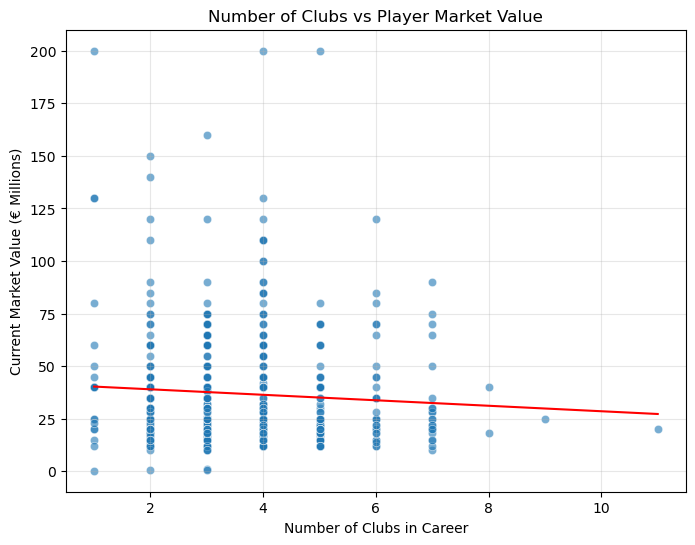

```python
import numpy as np
import matplotlib.pyplot as plt
import seaborn as sns

plt.figure(figsize=(8,6))

sns.scatterplot(
    data=players,
    x="num_clubs_career",
    y=y,
    alpha=0.6
)

m, b = np.polyfit(x, y, 1)

x_line = np.linspace(x.min(), x.max(), 100)
plt.plot(x_line, m * x_line + b, color="red")

plt.title("Number of Clubs vs Player Market Value")
plt.xlabel("Number of Clubs in Career")
plt.ylabel("Current Market Value (€ Millions)")
plt.grid(alpha=0.3)

plt.show()
```

Given our p value is 0.119 so p-val > $\alpha$ = 0.05, we fail to reject the null hypothesis. This means that this data does not provide any statistically significant evidence that the number of clubs a player has played relates to their current market value. Although the regression line in the scatter plot is slightly negative, the correlation coefficient of -0.069 tells us that this relationship is very marginal and is extremely weak. Therefore, the number of clubs a player has been on does not seem to meaningfully explain any variation in player market value.

The scatter plot also shows a wide spread of market values across almost all number of clubs, meaning that players can have both high and low market values regardless of how many clubs they have played for. This suggests that other factors are likely much more influential in determining a player’s market value. For example, variables like player age, performance statistics, position, or league quality likely have a stronger effect on valuation than how many times they have transferred clubs. Also, some players may change clubs frequently due to transfers between strong teams, while others remain at one club for long periods even though they may have lower market value, which could weaken any simple relationship between the two variables even more.

Therefore, while the frequency of transferring teams might intuitively seem related to player value, our analysis suggests that the number of clubs played for is not a strong predictor of market value within this dataset. Continuing analysis with additional variables would likely provide a better understanding of the factors that influence player valuation.

**Hypothesis Testing (One-way ANOVA)**

We will conduct a hypothesis test to determine whether player age group has an effect on current market value. Since age has been divided into multiple categories and we want to compare the mean market value across these groups, we will use a one-way ANOVA test.

H₀: The mean current market value is the same across all age groups.

Hₐ: At least one age group has a different mean current market value.

The independent variable is age_group, which includes the categories Under 23, 23–27, 28–32, and 32+. The dependent variable is current_value_eur.

```
Mean Market Value by Age Group:
age_group
23-27       3.906210e+07
28-32       3.015730e+07
32+         3.359701e+07
Under 23    3.938947e+07
Name: current_value_eur, dtype: float64
```

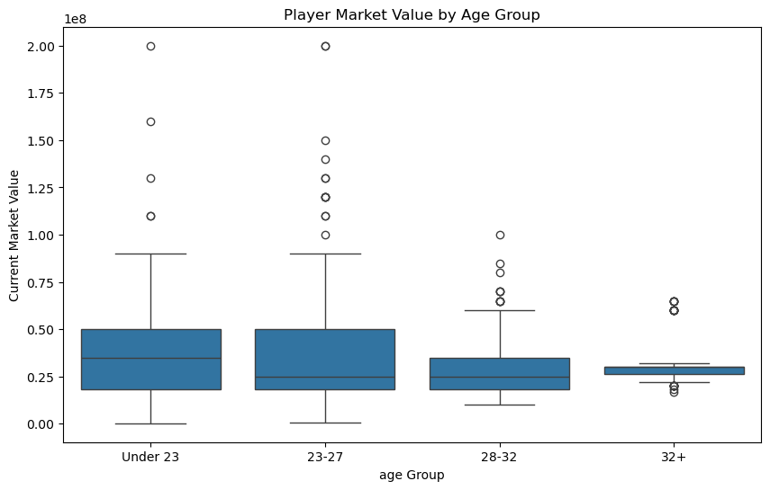

```python
import scipy.stats as stats


def assign_age_group(age):
    if age < 23:
        return "Under 23"
    elif age < 28:
        return "23-27"
    elif age < 33:
        return "28-32"
    else:
        return "32+"


players["age_group"] = players["age"].apply(assign_age_group)
print ("Mean Market Value by Age Group:")
print(players.groupby("age_group", observed=True)["current_value_eur"].mean())

labels = ["Under 23", "23-27", "28-32", "32+"]
plt.figure(figsize=(10,6))

sns.boxplot(
    data=players,
    x="age_group",
    y="current_value_eur",
    order=labels
)

plt.title("Player Market Value by Age Group")
plt.xlabel("age Group")
plt.ylabel("Current Market Value")
plt.show()
```

The table shows the average market value in euros for each age group. Players under 23 have the highest average market value and players in the 23-27 age group follow closely behind. The 32+ group has a lower average value, while the 28-32 group has the lowest average value among the four groups. However, these averages should be interpreted carefully because market value is right-skewed, meaning a few very high-value players can strongly affect the mean.

```python
under_23 = players.loc[players["age_group"] == "Under 23", "current_value_eur"].dropna()
age_23_to_27 = players.loc[players["age_group"] == "23-27", "current_value_eur"].dropna()
age_28_to_32 = players.loc[players["age_group"] == "28-32", "current_value_eur"].dropna()
over_32 = players.loc[players["age_group"] == "32+", "current_value_eur"].dropna()

f_stat, p_val = stats.f_oneway(under_23, age_23_to_27, age_28_to_32, over_32)

print(f"\nANOVA Results:")
print(f"F-statistic: {f_stat}")
print(f"P-value: {p_val}")
```

```
ANOVA Results:
F-statistic: 2.909215663130835
P-value: 0.03414690939410667
```

We did an ANOVA test to see whether or not a player's age group has a significant effect on their current market valuation. The one-way ANOVA test produced an F-statistic of 2.91 and a p-value of 0.034. Since the p-value is less than the significance level of 0.05, we reject the null hypothesis. The null hypothesis will be that the mean market value is the same across all age groups. The alternative hypothesis will be that at least one age group has a significantly different average market value.

Since the p-value is below the significance level .05, we reject the null hypothesis, which means that age group does in fact have an effect on market value.

## Primary Analysis: Machine Learning (Two Parts, Classification + Regression)

### Classification: Predicting Career Trajectory

We answer the first question from the introduction: **can we predict a player's career trajectory class from observable career statistics?**

The five trajectory labels in the dataset are `rising_star`, `growing`, `stable`, `declining`, and `falling_sharply`. These represent where a player's market value is headed - not where it currently sits.

We use only features that describe career patterns observable independently of the trajectory label itself. Features that are definitionally derived from the label are excluded.

We test one model:

of them.

The data is split 80% for training and 20% for testing. We use stratification, which ensures the class proportions are the same in both splits (important since the classes are imbalanced). We also run 5-fold cross-validation, giving a more reliable accuracy estimate.

### Additional Imports

```python
from sklearn.ensemble import RandomForestClassifier, RandomForestRegressor, GradientBoostingRegressor
from sklearn.linear_model import LinearRegression, Ridge
from sklearn.model_selection import train_test_split, cross_val_score
from sklearn.preprocessing import LabelEncoder, StandardScaler
from sklearn.metrics import (
    confusion_matrix, ConfusionMatrixDisplay,
    classification_report, r2_score, mean_absolute_error, mean_squared_error
)
```

### Feature Selection

These columns were excluded:

- **`post_peak_decline_pct`**: This measures how much a player's value has dropped from their peak. The trajectory label is assigned based on this number. So the model wouldn't be learning anything if we used this.
- **`is_at_peak`**: A 1/0 flag for whether the player is currently at their highest ever value. This is excluded because it directly encodes the outcome we're trying to predict
- **`ever_100m`, `ever_50m`, `ever_10m`**: Including them would essentially give the model an idea of the right answer, which we don't want.

```python
# Features for classification
clf_features = [
    "age", "age_at_peak", "career_span_years", "years_to_peak",
    "value_cagr", "value_to_peak_cagr", "value_multiplier_x",
    "value_volatility", "mean_yoy_growth_rate", "num_valuation_points",
    "num_clubs_career", "current_value_eur", "first_value_eur"
]
```

```python
x = players[clf_features].copy()
y = players["trajectory"].copy()

# Convert labels to numbers: declining=0, falling_sharply=1, growing=2, etc.
encoder = LabelEncoder()
labels_encoded = encoder.fit_transform(y)

# Check how many players fall into each trajectory class
print("Class distribution:")
for clas in encoder.classes_:
    count = (y == clas).sum()
    print(f"{clas}: {count} players ({count / len(y) * 100}%)")
```

```
Class distribution:
declining: 73 players (14.37007874015748%)
falling_sharply: 26 players (5.118110236220472%)
growing: 228 players (44.881889763779526%)
rising_star: 117 players (23.031496062992126%)
stable: 64 players (12.598425196850393%)
```

```python
# Split into 80% training and 20% test
x_train, x_test, y_train, y_test = train_test_split(
    x, labels_encoded, test_size=0.2, random_state=42, stratify=labels_encoded
)

print(f"Training set: {len(x_train)} players")
print(f"Test set: {len(x_test)} players")
```

```
Training set: 406 players
Test set: 102 players
```

```python
# Random Forest: 200 trees, each trained on a random subset of the data and features
rf = RandomForestClassifier(n_estimators=200, random_state=42, criterion="entropy")
rf.fit(x_train, y_train)
rf_predictions = rf.predict(x_test)
rf_accuracy = (rf_predictions == y_test).mean()
rf_cv_scores = cross_val_score(rf, x, labels_encoded, cv=5)

print(f"Random Forest - Test Accuracy: {rf_accuracy:.4f}")
print(f"Random Forest - 5-fold CV: {rf_cv_scores.mean():.4f} +- {rf_cv_scores.std():.4f}")
print()
print("Full Classification Report:")
print(classification_report(y_test, rf_predictions, target_names=encoder.classes_))
```

```
Random Forest - Test Accuracy: 0.5980
Random Forest - 5-fold CV: 0.5651 +- 0.0356

Full Classification Report:
                 precision    recall  f1-score   support

      declining       0.56      0.67      0.61        15
falling_sharply       1.00      0.40      0.57         5
        growing       0.61      0.83      0.70        46
    rising_star       0.71      0.43      0.54        23
         stable       0.17      0.08      0.11        13

       accuracy                           0.60       102
      macro avg       0.61      0.48      0.51       102
   weighted avg       0.59      0.60      0.57       102
```

#### Classification Report Analysis

The model did the best at identifying players in the `growing` category. For this category, the model has a recall of 0.83 which means it correctly identifies about 83% of the players who are actually growing. It also has decent precision score of 0.61 meaning that when the model predicts a player is growing, it is correct around 61% of the time. Additionally, the F1 score of 0.70 shows that the model balances the precision and recall well. The model also does decently with the declining category. Here, the model has a recall of 0.67 meaning it correctly identifies about 67% of the players who are actually declining. It also has a precision score of 0.56, meaning that when the model predicts a player is declining, it is correct about 56% of the time. The F1 score for declining is 0.61, which shows that the model has a decent balance between finding declining players and making correct predictions of declining.

The model has mixed performance on the `rising_star` category with a precision of 0.71 but a recall of 0.43. This means that even though when it predicts a player is a rising star it is correct about 71% of the time, it only correctly identifies less than half of the actual rising star players. This means it misses many players that are actually rising stars, accidentally classifying them as growing instead. This makes sense because both categories involve increasing market value so the difference between steady growth and rapid growth may be hard for the model to distinguish between.

Smaller classes or classes that are not well separated, such as `stable` and `falling_sharply`, perform much worse. Stable has a very weak performance with a precision of 0.17, recall of 0.08 and F1 score of 0.11. The falling_sharply class is very imbalanced with a high precision of 1.00 but a very low recall of 0.40. This means that while the model is almost always right when it predicts a player is falling sharply, it misses most of the actual players that are in this class.

Overall, the model performs the best when the career trend has a clear direction like for the growing or declining metrics and struggles more with categories like stable or falling_sharply, where the patterns are less distinct or there are fewer examples.

#### Confusion Matrix

The confusion matrix shows where the Random Forest is right and where it gets confused. Each row is the true class, each column is what the model predicted. Correct predictions run along the diagonal. Off-diagonal entries are mistakes.

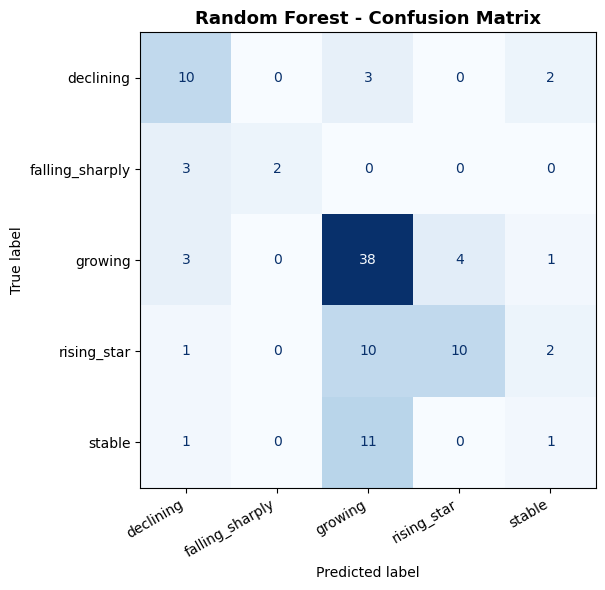

```python
cm = confusion_matrix(y_test, rf_predictions)
disp = ConfusionMatrixDisplay(confusion_matrix=cm, display_labels=encoder.classes_)

fig, ax = plt.subplots(figsize=(8, 6))
disp.plot(ax=ax, cmap="Blues", colorbar=False)
ax.set_title("Random Forest - Confusion Matrix", fontsize=13, fontweight="bold")
plt.xticks(rotation=30, ha="right")
plt.tight_layout()
plt.show()
```

#### Confusion Matrix Analysis

The model's strongest performance is on `growing` (as we previously said) - 38/46 correctly identified, which makes sense as it's the largest class with the most training examples.

The biggest weakness is `stable`- 1/13 stable players were correctly predicted, with 11 being misclassified as `growing`. This is the model's most common mistake, the model defaults to `growing` when uncertain.

`rising_star` also struggled, with 10/23 correctly predicted and most of the rest being called `growing`. The two classes are simply too similar in career dynamics for the model to reliably separate them with the features we have.

`falling_sharply` got 2/5 correct which is understandable given how few examples exist in the test set.

#### Feature Importances

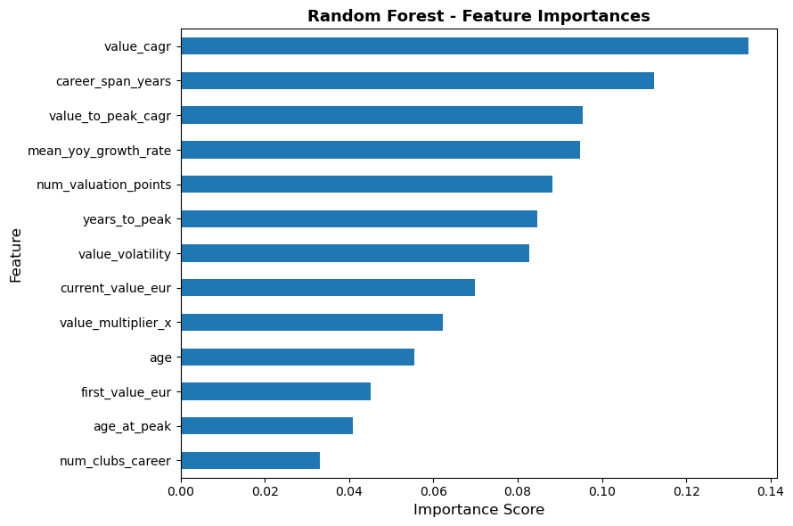

```python
importances = pd.Series(rf.feature_importances_, index=clf_features).sort_values(ascending=True)
fig, ax = plt.subplots(figsize=(9, 6))
importances.plot(kind="barh", ax=ax)
ax.set_title("Random Forest - Feature Importances", fontsize=13, fontweight="bold")
ax.set_xlabel("Importance Score", fontsize=12)
ax.set_ylabel("Feature", fontsize=12)
plt.tight_layout()
plt.show()
```

#### Feature Importance Analysis

`value_cagr` is the most important feature, followed closely by `career_span_years`, `value_to_peak_cagr`, and `mean_yoy_growth_rate`. The dominance of growth rate metrics confirms that trajectory is about momentum.

`career_span_years` ranking 2nd is notable. Players labeled `declining` or `falling_sharply` tend to have longer careers simply because they've had more time to peak and come back down, while `rising_star` players tend to have shorter career histories.

At the bottom are `num_clubs_career`, `age_at_peak`, `first_value_eur`, and `age`. All with low importance scores.

#### Accuracy

The gray dotted line marks the majority-class baseline (~45%) - what a model would score if it just always guessed `growing`. Scoring above this line means the model has actually learned something useful from the features.

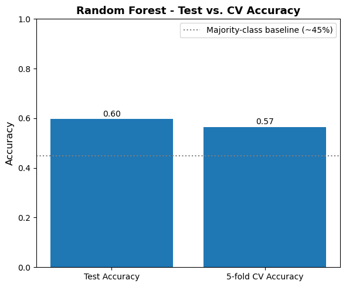

```python
fig, ax = plt.subplots(figsize=(6, 5))

bars = ax.bar(
    ["Test Accuracy", "5-fold CV Accuracy"],
    [rf_accuracy, rf_cv_scores.mean()],
)

ax.axhline(0.45, color="gray", linestyle=":", linewidth=1.5, label="Majority-class baseline (~45%)")
ax.set_ylim(0, 1.0)
ax.set_ylabel("Accuracy", fontsize=12)
ax.set_title("Random Forest - Test vs. CV Accuracy", fontsize=13, fontweight="bold")
ax.legend()

# Show numbers
ax.text(bars[0].get_x() + bars[0].get_width() / 2, rf_accuracy + 0.01, f"{rf_accuracy:.2f}", ha="center")
ax.text(bars[1].get_x() + bars[1].get_width() / 2, rf_cv_scores.mean() + 0.01, f"{rf_cv_scores.mean():.2f}", ha="center")

plt.tight_layout()
plt.show()
```

### Regression: Predicting Future Peak Market Value from Early-Career Signals

We now answer the second question from the introduction: **how well can we predict a player's eventual peak market value from early-career features?**

Earlier, we considered using both early- and mid-career information. However, the dataset shows that most players reach their peak market value by their mid-career years, especially around ages 23-25. If we used valuation history through age 25, many rows would already contain the player's peak, which isn't the goal.

We use only valuation snapshots available by **age 21**. This gives us early-career trajectory information while avoiding most peak-value leakage. We also exclude players whose peak had already occurred by their age 21, so every remaining row asks the model to predict a peak that happens in the future.

We compare four regressors (Linear Regression, Ridge Regression, Random Forest, and Gradient Boosting) on their ability to predict `log1p(peak_value_eur)` from early-career features alone.

#### Early-Career Feature Engineering

For each player, we build one row using valuation snapshots at or before age 21 only. Each row summarizes the player's early market-value path:

- `first_value_eur`: the player's earliest recorded value before the cutoff
- `value_at_cutoff`: the latest known value at or before age 21
- `max_value_so_far`: highest value observed before the cutoff
- `value_growth_so_far`: ratio of cutoff value to first recorded value
- `slope_so_far`: slope from a least-squares fit of value vs days since first snapshot
- `cagr_so_far`: compound annual growth rate across the observed early-career window
- `volatility_so_far`: standard deviation of percentage change between consecutive snapshots
- `age_at_first`: player's age at their earliest snapshot
- `age_at_cutoff_snapshot`: age at the latest snapshot used for prediction
- `days_observed`: total time span covered before the cutoff
- `num_snapshots_so_far`: number of valuation snapshots available before the cutoff
- `num_clubs_so_far`: number of unique clubs observed before the cutoff
- `changed_club_so_far`: whether the player had already changed clubs before the cutoff

```python
EARLY_CAREER_CUTOFF = 21
MIN_SNAPSHOTS = 2

hist_sorted = history.sort_values(["player_id", "valuation_date"])
player_targets = players[["player_id", "peak_value_eur", "peak_date"]]

# Only use information that would have been available at or before age 21.
early_history = hist_sorted[hist_sorted["age_at_date"] <= EARLY_CAREER_CUTOFF].copy()
snapshot_counts = early_history.groupby("player_id").size()
eligible_ids = snapshot_counts[snapshot_counts >= MIN_SNAPSHOTS].index
early_history = early_history[early_history["player_id"].isin(eligible_ids)]

def early_career_features(g):
    g = g.sort_values("valuation_date").reset_index(drop=True)

    # Days elapsed since the player's first valuation
    days = (g["valuation_date"] - g["valuation_date"].iloc[0]).dt.days.to_numpy(dtype=float)
    vals = g["value_eur"].to_numpy(dtype=float)

    # How fast is the value growing in euros per day
    slope = np.polyfit(days, vals, 1)[0] if len(vals) > 1 and days.std() > 0 else 0.0

    # Compound annual growth rate from first to last snapshot
    span_years = max((days[-1] - days[0]) / 365.25, 1e-6)
    cagr = (vals[-1] / vals[0]) ** (1 / span_years) - 1 if vals[0] > 0 else 0.0

     # How volatile has the value been, high volatility means inconsistent growth
    prev = np.where(vals[:-1] == 0, 1, vals[:-1])
    pct = np.diff(vals) / prev
    volatility = pct.std() if len(pct) > 1 else 0.0


    growth = vals[-1] / vals[0] if vals[0] > 0 else np.nan
    num_clubs = g["club"].nunique()

    return pd.Series({
        "cutoff_age": EARLY_CAREER_CUTOFF,
        "cutoff_date": g["valuation_date"].iloc[-1],
        "first_value_eur": vals[0],
        "value_at_cutoff": vals[-1],
        "max_value_so_far": vals.max(),
        "value_growth_so_far": growth,
        "slope_so_far": slope,
        "cagr_so_far": cagr,
        "volatility_so_far": volatility,
        "age_at_first": g["age_at_date"].iloc[0],
        "age_at_cutoff_snapshot": g["age_at_date"].iloc[-1],
        "days_observed": days[-1] - days[0],
        "num_snapshots_so_far": len(g),
        "num_clubs_so_far": num_clubs,
        "changed_club_so_far": int(num_clubs > 1),
    })

# Compute early career features for every eligible player
early_features_df = (
    early_history.groupby("player_id")
                 .apply(early_career_features, include_groups=False)
                 .reset_index()
)


# Attach the target (peak value) to each player
early_features_df = early_features_df.merge(player_targets, on="player_id", how="left")
before_peak_filter = len(early_features_df)
early_features_df = early_features_df.dropna(subset=["peak_value_eur", "peak_date", "cutoff_date"])

# Exclude players whose peak was already known by the age 21.
early_features_df = early_features_df[
    early_features_df["peak_date"] > early_features_df["cutoff_date"]
].reset_index(drop=True)

print(f"Players with >= {MIN_SNAPSHOTS} snapshots by age {EARLY_CAREER_CUTOFF}: {before_peak_filter}")
print(f"Players kept after excluding already-peaked careers: {len(early_features_df)}")
print(f"Players dropped by forward-looking peak filter: {before_peak_filter - len(early_features_df)}")

# Check: every retained row should be predicting a future peak.
print(f"Rows with peak_date <= cutoff_date: {(early_features_df['peak_date'] <= early_features_df['cutoff_date']).sum()}")

early_features_df.head()
```

```
Players with >= 2 snapshots by age 21: 502
Players kept after excluding already-peaked careers: 356
Players dropped by forward-looking peak filter: 146
Rows with peak_date <= cutoff_date: 0
```

|  | player_id | cutoff_age | cutoff_date | first_value_eur | value_at_cutoff | max_value_so_far | value_growth_so_far | slope_so_far | cagr_so_far | volatility_so_far | age_at_first | age_at_cutoff_snapshot | days_observed | num_snapshots_so_far | num_clubs_so_far | changed_club_so_far | peak_value_eur | peak_date |
| --- | --- | --- | --- | --- | --- | --- | --- | --- | --- | --- | --- | --- | --- | --- | --- | --- | --- | --- |
| 0 | 108390 | 21 | 2014-01-23 | 50000.0 | 25000000.0 | 25000000.0 | 500.000000 | 17296.043604 | 2.794899 | 1.502548 | 17 | 21 | 1702.0 | 13 | 3 | 1 | 75000000 | 2020-10-07 |
| 1 | 121483 | 21 | 2014-10-05 | 150000.0 | 8000000.0 | 16000000.0 | 53.333333 | 4750.574091 | 1.160017 | 1.024748 | 16 | 21 | 1886.0 | 10 | 5 | 1 | 100000000 | 2019-06-10 |
| 2 | 126414 | 21 | 2015-07-01 | 150000.0 | 18000000.0 | 18000000.0 | 120.000000 | 15319.167438 | 3.092067 | 0.628073 | 17 | 21 | 1241.0 | 12 | 3 | 1 | 45000000 | 2024-06-04 |
| 3 | 132098 | 21 | 2015-07-01 | 500000.0 | 25000000.0 | 25000000.0 | 50.000000 | 21414.191628 | 3.443800 | 2.126225 | 19 | 21 | 958.0 | 5 | 2 | 1 | 150000000 | 2018-05-27 |
| 4 | 153084 | 21 | 2016-07-22 | 600000.0 | 15000000.0 | 15000000.0 | 25.000000 | 8345.791341 | 1.215467 | 0.728067 | 17 | 21 | 1478.0 | 10 | 2 | 1 | 70000000 | 2021-02-09 |

#### Train/Test Split

We log-transform the target (`np.log1p(peak_value_eur)`) since peak values are right-skewed across 300K–200M euros. Predictions are back-transformed with `expm1` for evaluation in euros. Since there is exactly one row per player, a standard 80/20 train/test split is sufficient.

```python
feature_cols = [
    "first_value_eur", "value_at_cutoff", "max_value_so_far", "value_growth_so_far",
    "slope_so_far", "cagr_so_far", "volatility_so_far", "age_at_first",
    "age_at_cutoff_snapshot", "days_observed", "num_snapshots_so_far",
    "num_clubs_so_far", "changed_club_so_far"
]

X = early_features_df[feature_cols].values

# Log-transform them to prevent outliers from dominating the loss
y_log = np.log1p(early_features_df["peak_value_eur"].values)
y_eur = early_features_df["peak_value_eur"].values

# Split into training and test sets
X_train, X_test, y_train, y_test, y_train_eur, y_test_eur = train_test_split(
    X, y_log, y_eur, test_size=0.2, random_state=42
)

print(f"Final regression dataset: {len(early_features_df)} players")
print(f"Training set: {len(X_train)} players")
print(f"Test set: {len(X_test)} players")
print(f"Features used: {len(feature_cols)}")
```

```
Final regression dataset: 356 players
Training set: 284 players
Test set: 72 players
Features used: 13
```

#### Models

We test four different models to predict peak value ranging from simple to complex:

1. **Linear Regression**: the simplest baseline. Fits a straight line through the data.
2. **Ridge Regression**: a version of linear regression that adds a penalty for large coefficients, which helps when features are correlated with each other.
3. **Random Forest** (200 trees): Handles nonlinear relationships without any feature scaling needed.
4. **Gradient Boosting** (200 trees): builds trees sequentially, where each tree corrects the mistakes of the previous one.

All models are trained on `log1p(peak_value_eur)` rather than the raw euro value. This is because peak values are so skewed, without the log transform the model would focus almost entirely on getting the 150M+ euro outliers right and perform poorly on everyone else. After predicting, we back-transform with `np.expm1` to report errors in actual euros.

```python
# Ridge needs features on the same scale
scaler = StandardScaler()
X_train_s = scaler.fit_transform(X_train)
X_test_s = scaler.transform(X_test)
X_all_s = StandardScaler().fit_transform(X)

models = {
    "Linear Regression": (LinearRegression(), X_train, X_test, X),
    "Ridge Regression": (Ridge(alpha=1.0, random_state=42), X_train_s, X_test_s, X_all_s),
    "Random Forest": (RandomForestRegressor(n_estimators=200, random_state=42), X_train, X_test, X),
    "Gradient Boosting": (GradientBoostingRegressor(n_estimators=200, random_state=42), X_train, X_test, X),
}

results = []
fitted_models = {}

for name, (model, X_tr, X_te, X_full) in models.items():
    # Train
    model.fit(X_tr, y_train)

    # Predict in log space, then convert back to eurors
    pred_log = model.predict(X_te)
    pred_eur = np.expm1(pred_log)

    # Compute metrics
    r2_log = r2_score(y_test, pred_log)
    r2_eur = r2_score(y_test_eur, pred_eur)
    mae_eur = mean_absolute_error(y_test_eur, pred_eur) / 1e6
    rmse_eur = np.sqrt(mean_squared_error(y_test_eur, pred_eur)) / 1e6
    cv = cross_val_score(model, X_full, y_log, cv=5, scoring="r2")

    results.append({
        "Model": name,
        "Players": len(early_features_df),
        "R^2 (log)": r2_log,
        "R^2 (euros)": r2_eur,
        "MAE (M euros)": mae_eur,
        "RMSE (M euros)": rmse_eur,
        "CV R^2 (mean)": cv.mean(),
        "CV R^2 (std)": cv.std(),
    })
    fitted_models[name] = (model, pred_log, pred_eur)

results_df = pd.DataFrame(results).set_index("Model")
results_df.round(4)
```

| Model | Players | R^2 (log) | R^2 (euros) | MAE (M euros) | RMSE (M euros) | CV R^2 (mean) | CV R^2 (std) |
| --- | --- | --- | --- | --- | --- | --- | --- |
| Linear Regression | 356 | 0.3615 | 0.2434 | 18.5388 | 28.4105 | 0.2426 | 0.1323 |
| Ridge Regression | 356 | 0.3630 | 0.2443 | 18.5312 | 28.3947 | 0.2452 | 0.1311 |
| Random Forest | 356 | 0.3484 | 0.3228 | 17.6757 | 26.8783 | 0.1352 | 0.1830 |
| Gradient Boosting | 356 | 0.2532 | 0.2493 | 18.6542 | 28.3000 | 0.0965 | 0.2205 |

#### Model Results Analysis

None of the four models perform strongly, with R^2 (log) scores ranging from 0.25 to 0.36. This means the best model explains only about 36% of the variance in peak value using only information available by age 21. This is actually a reasonable result given how early in a career we're making predictions.

**Linear Regression and Ridge** perform nearly identically, which tells us that the relationship between early career features and peak value is roughly linear, and that multicollinearity between features isn't a major problem here. Ridge's regularization adds almost nothing over plain linear regression.

**Random Forest** has a slightly lower R^2 in log space (0.35) than the Linear/Ridge models but the best performance in euro space (R^2 = 0.32, MAE = 17.7M, RMSE = 26.9M). This suggests it handles the high-value outliers better than the linear models.

**Gradient Boosting** is the weakest overall. Lower R^2 and the highest CV standard deviation (0.22), indicating it's unstable across different data splits.

The MAE of ~17-19M across all models means predictions are off by roughly that amount on average. Given that peak values range from a few million to 200M, this error is important but not surprising. Predicting a player's career ceiling from age 21 data alone is hard. The Random Forest is the most practical choice here.

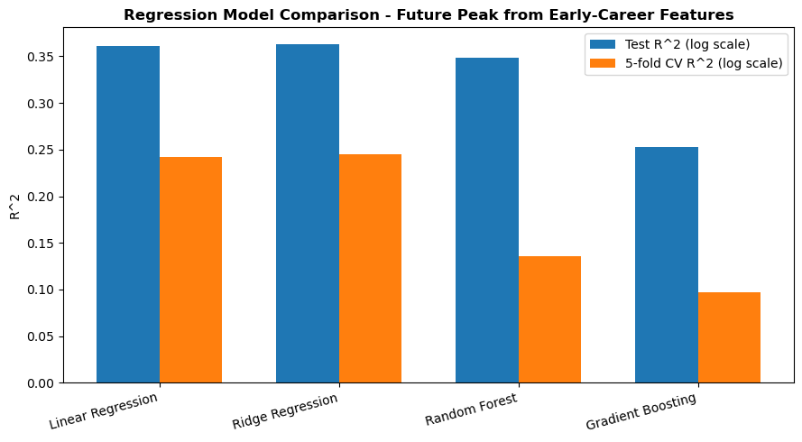

```python
fig, ax = plt.subplots(figsize=(9, 5))
x_pos = np.arange(len(results_df))
width = 0.35

# Side by side bars: test R^2 on the left, CV R^2 on the right
ax.bar(x_pos - width/2, results_df["R^2 (log)"], width, label="Test R^2 (log scale)")
ax.bar(x_pos + width/2, results_df["CV R^2 (mean)"], width, label="5-fold CV R^2 (log scale)", capsize=4)

ax.set_xticks(x_pos)
ax.set_xticklabels(results_df.index, rotation=15, ha="right")
ax.set_ylabel("R^2")
ax.set_title("Regression Model Comparison - Future Peak from Early-Career Features",
             fontsize=12, fontweight="bold")

# R^2 = 0 means the model does no better than just predicting the mean every time
ax.legend()
plt.tight_layout()
plt.show()
```

#### Chart Analysis

The most important thing this chart reveals is the gap between test R^2 (blue) and CV R^2 (orange) for each model. A large gap means the model's test performance is somewhat misleading. Meaning it got lucky with that particular 80/20 split rather than generalizing well.

```
Best model by CV R^2: Ridge Regression
```

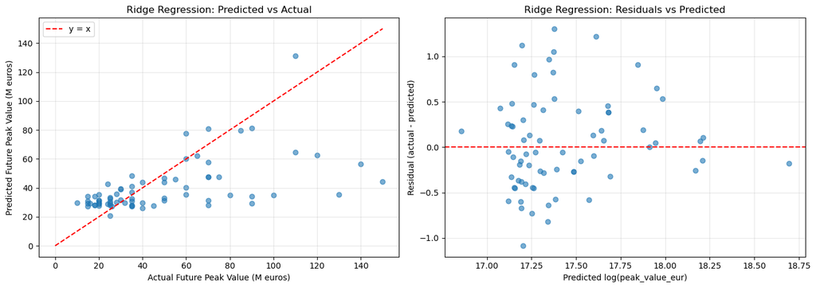

```python
best_name = results_df["CV R^2 (mean)"].idxmax()
best_model, best_pred_log, best_pred_eur = fitted_models[best_name]
print(f"Best model by CV R^2: {best_name}")

fig, axes = plt.subplots(1, 2, figsize=(14, 5))

# Predicted vs Actual (in euro millions)
axes[0].scatter(y_test_eur / 1e6, best_pred_eur / 1e6, alpha=0.6)
lim_max = max(y_test_eur.max(), best_pred_eur.max()) / 1e6
axes[0].plot([0, lim_max], [0, lim_max], color="red", linestyle="--", label="y = x")
axes[0].set_xlabel("Actual Future Peak Value (M euros)")
axes[0].set_ylabel("Predicted Future Peak Value (M euros)")
axes[0].set_title(f"{best_name}: Predicted vs Actual")
axes[0].legend()
axes[0].grid(alpha=0.3)

# Residuals on log scale
residuals = y_test - best_pred_log
axes[1].scatter(best_pred_log, residuals, alpha=0.6)
axes[1].axhline(0, color="red", linestyle="--")
axes[1].set_xlabel("Predicted log(peak_value_eur)")
axes[1].set_ylabel("Residual (actual - predicted)")
axes[1].set_title(f"{best_name}: Residuals vs Predicted")
axes[1].grid(alpha=0.3)

plt.tight_layout()
plt.show()
```

#### Ridge Regression Diagnostics

**Residuals vs Predicted**: Residuals are roughly centered around zero but show a slight pattern. The model tends to overestimate low-value players and underestimate high-value ones.

#### Feature Importances

Both tree models score how much each early-career feature contributed to reducing prediction error. Plotting them side by side shows whether the tree models agree on which signals matter.

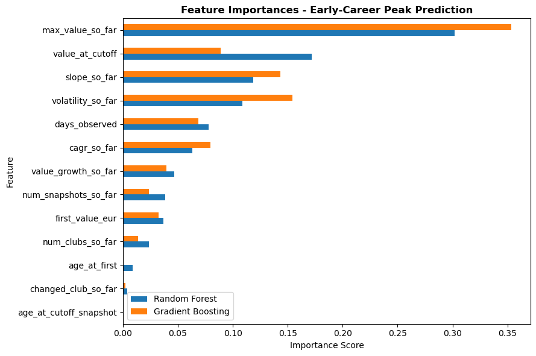

```python
rf_model = fitted_models["Random Forest"][0]
gbr_model = fitted_models["Gradient Boosting"][0]

imp_df = pd.DataFrame({
    "Random Forest": rf_model.feature_importances_,
    "Gradient Boosting": gbr_model.feature_importances_,
}, index=feature_cols).sort_values("Random Forest")

fig, ax = plt.subplots(figsize=(9, 6))
imp_df.plot(kind="barh", ax=ax)
ax.set_title("Feature Importances - Early-Career Peak Prediction",
             fontsize=12, fontweight="bold")
ax.set_xlabel("Importance Score")
ax.set_ylabel("Feature")
plt.tight_layout()
plt.show()
```

#### Feature Importance Analysis

Both models agree that `max_value_so_far` dominates by a wide margin (~30-35% importance). The highest value a player has reached by age 21 is the strongest signal of where their career ceiling ends up.

At the bottom sit `age_at_cutoff_snapshot`, `changed_club_so_far`, and `age_at_first`, all near zero. Age and transfer history add almost nothing once the value-based features are included.

Overall, these charts indicate that early-career growth trajectory is a meaningful, but flawed signal of a player's peak value. The model captures the trend well, but a large number of elite players remain difficult to predict purely from quantitative career features, without other context such as position and club reputation.

## Insights and Conclusions

#### Performance Summary

The classification model reached about 56-60% accuracy across many different data splits. This means it correctly predicted the career trajectory about 6 out of 10 times. The regression model performed a bit better. It had an R^2 of around 0.32, which means it explained about one third of the variance in peak value. The regression model's average error of predictdd peak value was about 18 million euros.

The classification model was much better at identifying players in the `growing` category than in the `stable` category. For example, the Random Forest had 83% recall for `growing`, meaning it correctly found most of the players whose market value was increasing. This makes sense because growing players likely have clearer patterns in the data like positive growth rates and rising market values. On the other hand, the model seemed to struggle with `stable` players. It only correctly identified 8% of them, which means it missed almost all players whose market value stayed relatively steady. Many of these stable players were incorrectly classified as `growing`. This suggests that the model had trouble telling the difference between players with small increases in value and players whose value was mostly stable.

For the regression model the main issue was that it underestimated superstar players. When a player’s actual peak value was extremely high, such as above 80 million euros, the model usually predicted a much lower value. This likely happened because superstar careers are rare and harder to learn from. Most players in the dataset have lower peak values so the model learned from this and would make safer predictions closer to the average instead of predicting extreme values.

### The Problem

Although from the numbers it looks like the model isn't very good, the performance is very reasonable when taking into account how difficult the task it was given really is. Predicting a player’s future career trajectory or peak market value is naturally a difficult task because of how many factors that are not fully captured in our dataset goes into the developement and trajectory of a player's entire career. Market value history can show trends, but it cannot account for everything that affects a player’s development.

For example, injuries can slow down or completely change a player’s career path, no matter how high their ceiling seems to be. A player’s club environment is another important factor. Things like coaching quality, playing time, team style, and the strength of the league they play in can have massive effects on what kind of player someone becomes. Even highly rated young players do not always become stars because development is unpredictable. Because of this, it makes sense that the models were not extremely accurate. The models were able to find some useful patterns, especially in obvious cases where a player’s value was clearly rising or falling. But, they struggled more with less obvious cases and extreme superstar players. This suggests that market value data is useful, but it is not enough by itself to fully predict if the player becomes a star. Becoming a star means becoming an outlier, and outliers are naturally hard for models to predict.

#### What We Learned

Even though the models weren't able to perfectly predict what we wanted them to, they were still able to give us a lot of useful information about things like player market value and career development. For instance, the classification model showed that market value trends are easier to identify when the direction is obvious. The model was much better at identifying players whose values were growing or declining than players whose values were stable. This tells us that strong upward or downward movement in market value creates patterns that the model can learn from.

The regression model also showed that early career value metrics can explain some of a player’s future peak value, but not all of it. Features like growth rate, early value, and value changes over time can help estimate future market value but they are not enough to perfectly predict which players will become superstars, as we saw the model underestimate players with extremely high peak values.

Overall, the models showed us that market value history is useful for understanding general career patterns, but it can not be used to fully predict success. The data can help identify broad trends (i.e. whether a player's value is moving upward or downward) but it cannot fully capture the unpredictable parts of player development.

#### Final Takeaway

If you were a football club trying to spot rising stars early, this analysis shows you'd need to do more than just run a model. Although the model would be a good start, you would still need human scouts who can assess things like positioning, mentality, and tactical awareness, information that cannot be captured in a dataset. A model that's right 60% of the time or explains 30% of the variance isn't good enough on its own for such a large investment and such a big decision. And although performance signals like valuation and growth do correlate with peak value, they do not guarantee anything. A lot of the difference between good players and superstars depends on circumstances no model can foresee.